# Possum reinvasion of the Otago Peninsula

Charlotte R. Patterson

2023-03-22

This code generates the summary statistics and plots from Patterson, Lustig, Seddon, Wilson & van Heezik (2023).

## Initial setup

Load packages and set working directory. Set directories for loading and saving files. Create a list of result sub-folder names for all scenarios

```r
library(tidyverse)

packages <- c("sf", "terra", "rasterVis", "matrixStats", "patchwork", "ggpubr", "reshape2", "viridis", "raster", "here")

walk(packages, require, character.only = T)

here::here()

main_wd <- "Z:\\Outcomes_23\\"

result_subf <- list('Worst_case_23',
                    'Maintenance_low_23',
                    'Maintenance_high_23',
                    'Buffer_maintenance_23',
                    'Maintenance_remove_23',
                    'Source_maintenance_23',
                    'Best_case_ALL_23',
                    'Landscape_barrier_23',
                    'Buffer_low_23',
                    'Buffer_mid_23',
                    'Buffer_high_23',
                    'Remove_low_23',
                    'Remove_mid_23',
                    'Remove_high_23',
                    'Source_high_23',
                    'Buffer_source_23',
                    'Buffer_remove_23',
                    'Source_remove_23',
                    'SourceRemoveBuffer23',
                    'BarrierWidthLow23',
                    'BarrierWidthMid23',
                    'BarrierWidthHigh23',
                    'ResKLow23',
                    'UrbanKLow23',
                    'UrbanKMid23',
                    'UrbanKHigh23',
                    'BarLUrbanL23',
                    'BarHUrbanH23')


# Set number of replications
nb_replication <- 50

# Function to calculate 2 x the standard error
se_func_2x <- function(x) (sd(x)/sqrt(length(x)))*2

# Function to calculate 2 x the standard error from standard deviation
se_func_fromsd <- function(x) (x/sqrt(50))*2
```

## Time to equilibrium (Appendix S4: Table S1 and Table S2)

Calculate the mean time to population equilibrium on the peninsula for each scenario. We defined an equilibrium population as being within 2% of the year-30 population (if complete repopulation occurred).

```r
#Generate the final empty dataframes
pest_perc <- NULL

# Create the function
dens_func <- function(x){

  print(x)

  #Create a unique output directory for the scenario
  output_dir <- dir.create(paste0(main_wd,"Figures", x), showWarnings = FALSE)

  # Initiate an empty data frame
  equilibrium <- NULL

  # Loop over replicates
  for (rep in seq(0,nb_replication-1)){

    # Set path to output file
    filename_nbpest <- paste0(main_wd, x, '\\2.monthly_stat_rep_',rep,'.gz')

    # Read file
    monthly_stat <- read.table(filename_nbpest)

    pest_density <- NULL

    # Extract possum abundance per replicate, convert to density (dividing by area of Otago Peninsula)
    pest_density <- cbind(pest_density, monthly_stat[,1]/9782.834) %>%
      as.data.frame()

    # Summarise monthly density across replicates to mean density per year
    pest_density_perc <- pest_density %>%
      mutate(year = rep(1:40, each = 12)) %>% #create a year column
      group_by(year) %>%
      dplyr::summarise(mean = mean(V1))

    # Trim to year 30 only
    pest_density_perc <- pest_density_perc[1:30,]

    # Calculate the percentage of the year-30 density
    pest_density_perc <- pest_density_perc %>%
      mutate(diff_final_mean = ((mean - as.numeric(pest_density_perc[30, 2])) / as.numeric(pest_density_perc[30, 2]))*100)

    # Filter just the years within 2% of the final 30-year abundance
    pest_density_perc <- pest_density_perc %>%
      filter(diff_final_mean < 2) %>%
      filter(diff_final_mean > -2)

    # Then take the first year where it reaches equilibrium
    equilibrium <- rbind(equilibrium, pest_density_perc[1,1] )

  }

  equilibrium <- as.data.frame(equilibrium) %>%
    mutate(scenario = as.factor(x), rep = row_number())

  pest_perc <<- dplyr::bind_rows(pest_perc, equilibrium)

}


# Run the first function
result_subf %>%
  map(dens_func)

# Summarise the data
data_summary_equilibrium <- pest_perc %>%
  group_by(scenario) %>%
  summarise(mean_equi_year = mean(year),
            se_equi_year_2x = se_func_2x(year),
            mean_minus_2se = mean_equi_year - se_equi_year_2x,
            mean_plus_2e = mean_equi_year + se_equi_year_2x)
```

```r
# Print the mean time to equilibrium
print(data_summary_equilibrium)
```

```
## # A tibble: 28 × 5
##    scenario           mean_equi_year se_equi_year_2x mean_minus_2se mean_plus_2e
##    <fct>                       <dbl>           <dbl>          <dbl>        <dbl>
##  1 Worst_case_23                15.6           0.392           15.2         16.0
##  2 Maintenance_low_23           17.9           0.529           17.4         18.4
##  3 Maintenance_high_…           21.2           0.543           20.6         21.7
##  4 Buffer_maintenanc…           20.9           0.546           20.4         21.4
##  5 Maintenance_remov…           NA            NA               NA           NA
##  6 Source_maintenanc…           21.4           0.707           20.7         22.1
##  7 Best_case_ALL_23             NA            NA               NA           NA
##  8 Landscape_barrier…           30             0               30           30
##  9 Buffer_low_23                15.9           0.433           15.5         16.4
## 10 Buffer_mid_23                15.4           0.274           15.1         15.7
## # ℹ 18 more rows
```

## Percentage invaded (Appendix S4: Table S1) and density at years 5, 10, 20, and 30 (Appendix S4: Table S3 and Table S4)

Calculate the percentage of replicates where the peninsula was invaded (defined as > 0.01 possums per ha by year 30). Calculate the mean density per scenario at years 5, 10, 20, and 30.

```r
# Generate the final empty dataframe
pest_final <- NULL

# Create the function
dens_func <- function(x){

  # Initiate an empty data frame
  pest_density <- NULL

  # Loop over replicates
  for (rep in seq(0,nb_replication-1)){

    # Set path to output file
    filename_nbpest <- paste0(main_wd, x, '\\2.monthly_stat_rep_',rep,'.gz')

    # Read file
    monthly_stat <- read.table(filename_nbpest)

    # Extract possum abundance per replicate, convert to density (dividing by area of Otago Peninsula)
    pest_density <- cbind(pest_density, (monthly_stat[,1]/9782.834))
  }

  pest_density <- as.data.frame(pest_density) %>%
    mutate(scenario = as.factor(x), month = row_number())

  pest_final <<- dplyr::bind_rows(pest_final, pest_density)

}



# Run the first function
result_subf %>%
  map(dens_func)


# Calculate the percentage invaded
n_invaded <- pest_final %>%
  filter(month == 360) %>%
  .[1:50] > 0.01

n_invaded <- rowSums(n_invaded)

data_summary_perc_invaded <- pest_final %>%
  filter(month == 360) %>%
  mutate(perc_invaded = (n_invaded/50)*100) %>%
  .[, c("scenario", "perc_invaded")]

print(data_summary_perc_invaded)

# Summarise the data to get densities at years 5, 10, 20, and 30
data_summary_density <- pest_final %>%
  rowwise() %>%
  mutate(mean_den_month = mean(c_across(1:50)),
    se_2x = se_func_2x(c_across(1:50)),
    mean_minus_2se = mean_den_month - se_2x,
    mean_plus_2se = mean_den_month + se_2x) %>%
  .[, 51:56] %>%
  filter( month %in% c(60, 120, 240, 360))
```

```r
# Print the density
print(data_summary_density)
```

```
## # A tibble: 112 × 6
## # Rowwise:
##    scenario            month mean_den_month   se_2x mean_minus_2se mean_plus_2se
##    <fct>               <int>          <dbl>   <dbl>          <dbl>         <dbl>
##  1 Worst_case_23          60         0.0983 2.37e-3         0.0960        0.101
##  2 Worst_case_23         120         0.294  1.91e-3         0.292         0.296
##  3 Worst_case_23         240         0.335  5.71e-4         0.334         0.335
##  4 Worst_case_23         360         0.336  5.66e-4         0.336         0.337
##  5 Maintenance_low_23     60         0.0762 1.84e-3         0.0744        0.0781
##  6 Maintenance_low_23    120         0.243  2.65e-3         0.241         0.246
##  7 Maintenance_low_23    240         0.298  6.22e-4         0.297         0.299
##  8 Maintenance_low_23    360         0.301  5.19e-4         0.300         0.302
##  9 Maintenance_high_23    60         0.0494 1.29e-3         0.0481        0.0507
## 10 Maintenance_high_23   120         0.164  2.95e-3         0.161         0.167
## # ℹ 102 more rows
```

```r
### Summarise the data first ###

# Generate the final empty dataframe
annual_pest_density_FINAL <- NULL

#Save annual pest density for plotting below

dens_func_plotting <- function(x){

  # Initiate an empty dataframe
  annual_pest_density <- NULL

  # Loop over replicates
  for (rep in seq(0, nb_replication-1)){

    # Set file path
    filename_nbpest <- paste0(main_wd, x, '\\2.monthly_stat_rep_',rep,'.gz')

    #Read file
    monthly_stat <- read.table(filename_nbpest) %>% .[,1]

    # Turn into annual stat
    annual_pest_stat <- (unname(tapply(monthly_stat, (seq_along(monthly_stat)-1) %/% 12, mean)))

    # Convert to possum density
    annual_pest_density <- cbind(annual_pest_density, (annual_pest_stat/9782.834)) # Set abundance as density by dividing by area of Otago Peninsula

  }

  annual_pest_density <- as.data.frame(annual_pest_density) %>%
    mutate(scenario = as.factor(x), year = row_number())

  # Remove to just year 30
  annual_pest_density <- annual_pest_density[!(annual_pest_density$year >=31 & annual_pest_density$year <= 40), ]

  annual_pest_density_FINAL <<- dplyr::bind_rows(annual_pest_density_FINAL, annual_pest_density)

}


#Run the first function
result_subf %>%
  map(dens_func_plotting)


# Summarise the data
data_summary_density_plotting <- annual_pest_density_FINAL %>%
  group_by(scenario, year) %>%
  mutate(mean = rowMeans(across(where(is.numeric)))) %>%
  mutate(sd = matrixStats::rowSds(as.matrix(across(where(is.numeric))))) %>%
  mutate(se2 = se_func_fromsd(sd))


### Fig 4a. Incomplete elimination ###

# Select scenarios without complete elimination
data_summary_not_elim <- data_summary_density_plotting %>%
  filter(scenario %in% c('Worst_case_23',
                         'Source_high_23',
                         'Remove_low_23',
                         'Buffer_low_23',
                         'Buffer_high_23',
                         'Buffer_mid_23',
                         'Remove_mid_23',
                         'Buffer_source_23',
                         'Maintenance_low_23',
                         'Maintenance_high_23',
                         'Source_maintenance_23',
                         'Buffer_maintenance_23'))

# Reorder factors for plotting
data_summary_not_elim$scenario <- factor(data_summary_not_elim$scenario,
         levels = c('Worst_case_23',
                         'Source_high_23',
                         'Remove_low_23',
                         'Buffer_low_23',
                         'Buffer_high_23',
                         'Buffer_mid_23',
                         'Remove_mid_23',
                         'Buffer_source_23',
                         'Maintenance_low_23',
                         'Maintenance_high_23',
                         'Source_maintenance_23',
                         'Buffer_maintenance_23'))

# Create the incomplete elimination plot
not_elim_plot <- data_summary_not_elim  %>%
  ggplot(aes(x = year, y = mean)) +
  geom_line(aes(color = scenario)) +
  theme_classic() +  # set background white
  theme(axis.text = element_text(size=12), axis.title = element_text(size=14), legend.text = element_text(size=10.5)) +
  labs(x = "Time (years)", y = "Possum density on the peninsula")  + # define axis label
geom_errorbar(aes(ymin = mean-se2, ymax = mean+se2, width=.1, color=scenario), alpha = 0.3) +
   scale_color_manual(name = "",
                        labels=c("Worst Case",
                                 "Source High",
                                 "Remove Low",
                                 "Buffer Low",
                                 "Buffer High",
                                 "Buffer Mid",
                                 "Remove Mid",
                                 "Buffer Source",
                                 "Maintenance Low",
                                 "Maintenance High",
                                 "Source Maintenance",
                                 "Buffer Maintenance"),
                        values = c("#56B4E9", "#619CFF", "#A58AFF", "#C77CFF", "#FF61CC","violetred4", "firebrick4", "#F8766D", "orangered1", "#CD9600", "#7CAE00", "darkgreen"))


# Optional - save the plot

#ggsave(plot = not_elim_plot , filename = paste0(main_wd, "\\incomplete_elim_density_plot.png"), w = 30, h = 15, units = "cm", dpi = 600, device = "png" )


### Fig. 4b. Complete elimination without Landscape Barrier ###

# Select scenarios with complete elimination
data_summary_complete_elim <- data_summary_density_plotting %>%
  filter(scenario %in% c('Remove_high_23',
                         'Source_remove_23',
                         'Buffer_remove_23',
                         'SourceRemoveBuffer23',
                         'Best_case_ALL_23'))

# Reorder factor levels for legend
data_summary_complete_elim$scenario <- factor(data_summary_complete_elim$scenario,
         levels = c(
                         'Remove_high_23',
                         'Source_remove_23',
                         'Buffer_remove_23',
                         'SourceRemoveBuffer23',
                         'Best_case_ALL_23'))

complete_elim_plot <- data_summary_complete_elim %>%
  ggplot(aes(x = year, y = mean)) +
  geom_line(aes(color = scenario)) +
  theme_classic() +  # set background white
  theme(axis.text = element_text(size=12), axis.title = element_text(size=14), legend.text = element_text(size=10.5)) +
  labs(x = "Time (years)", y = "Possum density on the peninsula")  + # define axis label
geom_errorbar(aes(ymin = mean-se2, ymax = mean+se2, width=.1, color=scenario), alpha = 0.3) +
  scale_color_manual(name = "",
                       labels = c("Remove High",
                                  "Source Remove",
                                  "Buffer Remove",
                                  "Buffer Source Remove",
                                  "Best Case"),
                       values = c( "#660066", "#F8766D","#CD9600", "#00BFC4", "#99CC00"))

# Optional - save the plot

# ggsave(plot = complete_elim_plot , filename = paste0(main_wd, "\\complete_elim_annual_density_plot.png"), w = 30, h = 15, units = "cm", dpi = 600, device = "png" )

### Fig. 4c. Landscape barrier plot ###

landscape_barr_plot <- data_summary_density_plotting %>%
  filter(scenario %in% c('Landscape_barrier_23')) %>%
  ggplot(aes(x = year, y = mean)) +
  geom_line(aes(color = scenario)) +
  theme_classic() +  # set background white
  theme(axis.text = element_text(size=12), axis.title = element_text(size=14), legend.text = element_text(size=10.5)) +
  labs(x = "Time (years)", y = "Possum density on the peninsula")  + # define axis label
geom_errorbar(aes(ymin = mean-se2, ymax = mean+se2, width=.1, color=scenario), alpha = 0.3) +
  scale_color_manual(name = "",
                       labels = c("Landscape Barrier"),
                     values = c("#E69F00"))


# Arrange all plots into figure
Annual_density_plot <- ggarrange(not_elim_plot + rremove("ylab") + rremove("xlab") , complete_elim_plot + rremove("ylab") + rremove("xlab"), landscape_barr_plot + rremove("ylab"), labels = c("(a)", "(b)", "(c)"), label.x = 0, label.y = 1.03, nrow = 3, ncol = 1, align = "v", legend = "top")

Annual_density_plot <- annotate_figure(Annual_density_plot, left = text_grob("Possum density on the peninsula", rot = 90, size = 14))
```

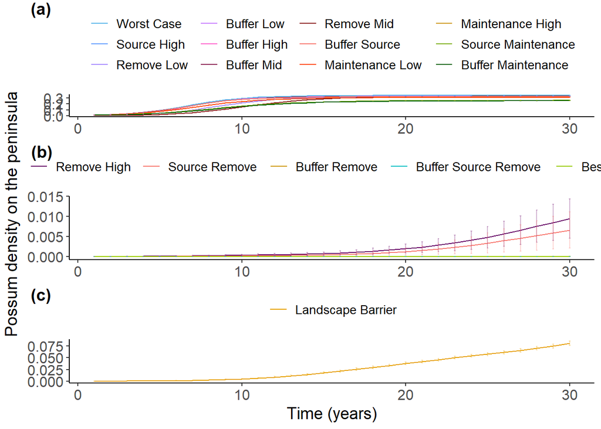

```r
#View plot
print(Annual_density_plot)
```

```r
# Optional - save the plot

# ggsave(plot = Annual_density_plot , filename = paste0(main_wd, "\\ALL_SCENARIOS_ARRANGED_density_plot.png"), w = 20.05, h = 24, units = "cm", dpi = 800, device = "png" )
```

## Plot annual density over time for sensitivity analysis (Appendix S4: Figure S1)

```r
# Fig. S1 (a)

# Select scenarios from sensitivity analysis and Landscape Barrier for comparison
data_summary_sensitivity_bar <- data_summary_density_plotting %>%
  filter(scenario %in% c('Landscape_barrier_23',
                         'BarrierWidthLow23',
                         'BarrierWidthMid23',
                         'BarrierWidthHigh23'))


# Create the sensitivity analysis plot
sensitivity_plot_bar <- data_summary_sensitivity_bar  %>%
  ggplot(aes(x = year, y = mean)) +
  geom_line(aes(color = scenario)) +
  theme_classic() +  # set background white
  theme(axis.text = element_text(size=12), axis.title = element_text(size=14), legend.text = element_text(size=10.5)) +
  labs(x = "Time (years)", y = "Possum density on the peninsula")  + # define axis label
  geom_errorbar(aes(ymin = mean-se2, ymax = mean+se2, width=.1, color=scenario), alpha = 0.3) +
  scale_color_manual(name = "",
                       labels = c("Landscape Barrier",
                                  "Barrier Width Low",
                                  "Barrier Width Mid",
                                  "Barrier Width High"),
                       values = c("#E69F00", "yellowgreen", "chartreuse4", "darkgreen"))

# Fig S1 (b)

# Select scenarios from sensitivity analysis and Landscape Barrier for comparison
data_summary_sensitivity_urbanK <- data_summary_density_plotting %>%
  filter(scenario %in% c('Landscape_barrier_23',
                         'ResKLow23',
                         'UrbanKLow23',
                         'UrbanKMid23',
                         'UrbanKHigh23'))


sensitivity_plot_urbanK <- data_summary_sensitivity_urbanK  %>%
  ggplot(aes(x = year, y = mean)) +
  geom_line(aes(color = scenario)) +
  theme_classic() +  # set background white
  theme(axis.text = element_text(size=12), axis.title = element_text(size=14), legend.text = element_text(size=10.5)) +
  labs(x = "Time (years)", y = "Possum density on the peninsula")  + # define axis label
  geom_errorbar(aes(ymin = mean-se2, ymax = mean+se2, width=.1, color=scenario), alpha = 0.3) +
  scale_color_manual(name = "",
                       labels = c("Landscape Barrier",
                                  "Residential K Zero",
                                  "Urban K Low",
                                  "Urban K Mid",
                                  "Urban K High"),
                       values = c("#E69F00", "tan4", "#00BFC4", "#00A9FF", "#000099"))

# Fig. S1 (c)

# Select scenarios from sensitivity analysis and Landscape Barrier for comparison
data_summary_sensitivity_bar_urbanK <- data_summary_density_plotting %>%
  filter(scenario %in% c('Landscape_barrier_23',
                         'BarLUrbanL23',
                         'BarHUrbanH23'))

# Create the sensitivity analysis plot
sensitivity_plot_bar_urbanK <- data_summary_sensitivity_bar_urbanK  %>%
  ggplot(aes(x = year, y = mean)) +
  geom_line(aes(color = scenario)) +
  theme_classic() +  # set background white
  theme(axis.text = element_text(size=12), axis.title = element_text(size=14), legend.text = element_text(size=10.5)) +
  labs(x = "Time (years)", y = "Possum density on the peninsula")  + # define axis label
  geom_errorbar(aes(ymin = mean-se2, ymax = mean+se2, width=.1, color=scenario), alpha = 0.3) +
  scale_color_manual(name = "",
                       labels = c("Landscape Barrier",
                                  "Barrier Low Urban K Low",
                                  "Barrier High Urban K High"),
                       values = c("#E69F00", "#C77CFF", "#FF61CC"))

Annual_density_sensitivity_plot <- ggarrange(sensitivity_plot_bar + rremove("ylab") + rremove("xlab") , sensitivity_plot_urbanK + rremove("ylab") + rremove("xlab"), sensitivity_plot_bar_urbanK + rremove("ylab"), labels = c("(a)", "(b)", "(c)"), label.x = 0, label.y = 1.03, nrow = 3, ncol = 1, align = "v", legend = "top")

Annual_density_sensitivity_plot <- annotate_figure(Annual_density_sensitivity_plot, left = text_grob("Possum density on the peninsula", rot = 90, size = 14))
```

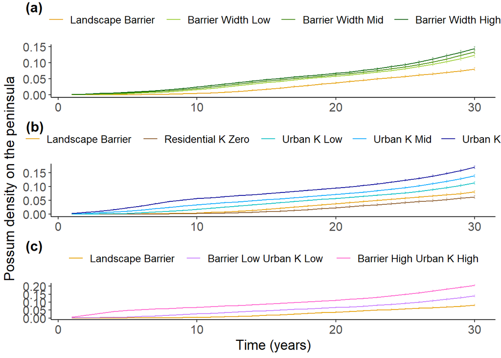

```r
#View plot
print(Annual_density_sensitivity_plot)
```

```r
# Optional - save the plot

# ggsave(plot = Annual_density_sensitivity_plot , filename = paste0(main_wd, "\\ALL_SENSITIVITY_SCENARIOS_ARRANGED_w_RESIDENTIAL_density_plot.png"), w = 20.05, h = 24, units = "cm", dpi = 800, device = "png" )
```

## Plotting the annual number of births and the number of juveniles immigrating onto the peninsula (Figure 5)

```r
### Plot 5a. Number of births ###

# Generate the final empty dataframe
pest_final_births <- NULL

# Create the function
birth_func <- function(x){

  # Initiate an empty data frame
  pest_births <- NULL

  # Loop over replicates
  for (rep in seq(0,nb_replication-1)){

    # Set path to output file
    filename_nbpest <- paste0(main_wd, x, '\\2.monthly_stat_rep_',rep,'.gz')

    # Read file
    monthly_stat <- read.table(filename_nbpest)

    # Extract only the birth data
    monthly_stat <- monthly_stat[,3]

    # Transform from monthly to annual value
    annual_births <- (unname(tapply(monthly_stat, (seq_along(monthly_stat)-1) %/% 12, sum)))

    # Add to the birth dataframe
    pest_births <- cbind(pest_births, annual_births)
  }

  colnames(pest_births) <- paste0("yearly_stat", 1:(ncol(pest_births)))

  # Save as a dataframe with associated scenario and year
  pest_births <- as.data.frame(pest_births) %>%
    mutate(scenario = as.factor(x), year = row_number())

  # Remove to just year 30
  pest_births <- pest_births[!(pest_births$year >=31 & pest_births$year <= 40), ]

  pest_final_births <<- dplyr::bind_rows(pest_final_births, pest_births)

}


# Run the first function
result_subf %>%
  map(birth_func)


# Summarise the data
data_summary_births <- pest_final_births %>%
  group_by(scenario, year) %>%
  mutate(mean = rowMeans(across(where(is.numeric)))) %>%
  mutate(sd = matrixStats::rowSds(as.matrix(across(where(is.numeric))))) %>%
  mutate(se2 = se_func_fromsd(sd)) %>%
  filter(scenario %in% c("Landscape_barrier_23", "Worst_case_23", "Best_case_ALL_23", "Remove_high_23"))

# Reorder factor levels for legend
data_summary_births$scenario <- factor(data_summary_births$scenario,
                                       levels = c('Worst_case_23',
                                                  'Landscape_barrier_23',
                                                  'Remove_high_23',
                                                  'Best_case_ALL_23'))


# Create the number of births plot
nb_births_plot <-data_summary_births %>%
  ggplot(aes(x = year, y = mean)) +
  geom_line(aes(color = scenario)) +
  theme_classic() +  # set background white
  theme(axis.text = element_text(size=12), axis.title = element_text(size=12.5), legend.text = element_text(size=10.5)) +
  labs(x = "Time (years)", y = "No. of births on the peninsula") +  # define axis label
  geom_errorbar(aes(ymin = mean-se2, ymax = mean+se2, width=.1, color=scenario), alpha = 0.3)+
  scale_color_manual(name = "",
                       labels = c(str_wrap('Incomplete elimination, no reinvasion control', 25),
                                  str_wrap('Complete elimination, no reinvasion control', 23),
                                  str_wrap('Complete elimination, moderate reinvasion control', 27),
                                  str_wrap('Complete elimination, high reinvasion control', 24)),
                     values = c("#56B4E9", "#E69F00", "#660066", "#99CC00"))


### Plot 5b. Immigration ###

# Generate the final empty dataframe
pest_final_imm <- NULL

# Create the function
imm_func <- function(x){

  # Initiate an empty data frame
  pest_imm <- NULL

  # Loop over replicates
  for (rep in seq(0,nb_replication-1)){

    # Set path to output file
    filename_nbpest <- paste0(main_wd, x, '\\2.monthly_stat_rep_',rep,'.gz')

    # Read file
    monthly_stat <- read.table(filename_nbpest)

    # Extract only the immigration data
    monthly_stat <- monthly_stat[,7]

    # Transform from monthly to annual value
    annual_imm <- (unname(tapply(monthly_stat, (seq_along(monthly_stat)-1) %/% 12, sum)))

    # Add to the immigration dataframe
    pest_imm <- cbind(pest_imm, annual_imm)
  }

  colnames(pest_imm) <- paste0("yearly_stat", 1:(ncol(pest_imm)))

  # Save as a dataframe with associated scenario and year
  pest_imm <- as.data.frame(pest_imm) %>%
    mutate(scenario = as.factor(x), year = row_number())

  # Remove to just year 30
  pest_imm <- pest_imm[!(pest_imm$year >=31 & pest_imm$year <= 40), ]

  pest_final_imm <<- dplyr::bind_rows(pest_final_imm, pest_imm)

}


# Run the first function
result_subf %>%
  map(imm_func)

# Summarise the data
data_summary_imm <- pest_final_imm %>%
  group_by(scenario, year) %>%
  mutate(mean = rowMeans(across(where(is.numeric)))) %>%
  mutate(sd = matrixStats::rowSds(as.matrix(across(where(is.numeric))))) %>%
  mutate(se2 = se_func_fromsd(sd)) %>%
  filter(scenario %in% c("Landscape_barrier_23", "Worst_case_23", "Best_case_ALL_23", "Remove_high_23"))

# Reorder factor levels for legend
data_summary_imm$scenario <- factor(data_summary_imm$scenario,
                                       levels = c('Worst_case_23',
                                                  'Landscape_barrier_23',
                                                  'Remove_high_23',
                                                  'Best_case_ALL_23'))

# Create the immigration plot
nb_immigrants_plot <-data_summary_imm %>%
  ggplot(aes(x = year, y = mean)) +
  geom_line(aes(color = scenario)) +
  theme_classic() +  # set background white
  theme(axis.text = element_text(size=12), axis.title = element_text(size=12.5), legend.text = element_text(size=10.5)) +
  labs(x = "Time (years)", y = "No. of juveniles immigrating onto the peninsula") +  # define axis label
  geom_errorbar(aes(ymin = mean-se2, ymax = mean+se2, width=.1, color=scenario), alpha = 0.3)+
  scale_color_manual(name = "",
                       labels = c(str_wrap('Incomplete elimination, no reinvasion control', 25),
                                  str_wrap('Complete elimination, no reinvasion control', 23),
                                  str_wrap('Complete elimination, moderate reinvasion control', 27),
                                  str_wrap('Complete elimination, high reinvasion control', 24)),
                     values = c("#56B4E9", "#E69F00", "#660066", "#99CC00"))


### Plot 5. Combined number of births and immigration ###

birth_vs_immigration_plot <- ggarrange(nb_births_plot + rremove("xlab"), nb_immigrants_plot, nrow = 2, ncol = 1, align = "v", common.legend = T, labels = c("(a)", "(b)"), label.x = -0.005,label.y = 1.10, font.label = list(size = 12))
```

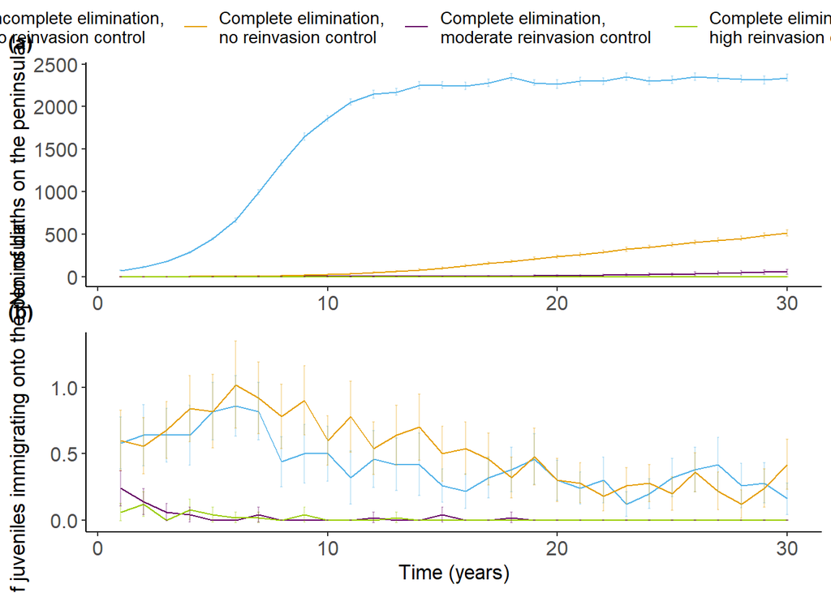

```r
print(birth_vs_immigration_plot)
```

```r
# Optional - save plot

# ggsave(plot = birth_vs_immigration_plot , filename = paste0(main_wd, "\\Birth_vs_immigration_plot.png"), w = 21.5, h = 21.2, units = "cm", dpi = 800, device = "png" )
```

## Plotting the annual number of births and the number of juveniles immigrating onto the peninsula for sensitivity analyses (Appendix S4: Figure S2:S4)

```r
### Plot S2a. Number of births ###

# Summarise the data
data_summary_births <- pest_final_births %>%
  group_by(scenario, year) %>%
  mutate(mean = rowMeans(across(where(is.numeric)))) %>%
  mutate(sd = matrixStats::rowSds(as.matrix(across(where(is.numeric))))) %>%
  mutate(se2 = se_func_fromsd(sd)) %>%
  filter(scenario %in% c('Landscape_barrier_23',
                         'BarrierWidthLow23',
                         'BarrierWidthMid23',
                         'BarrierWidthHigh23'))

# Reorder factor levels for legend
data_summary_births$scenario <- factor(data_summary_births$scenario,
                                       levels = c('Landscape_barrier_23',
                                                  'BarrierWidthLow23',
                                                  'BarrierWidthMid23',
                                                  'BarrierWidthHigh23'))


# Create the number of births plot
nb_births_plot <-data_summary_births %>%
  ggplot(aes(x = year, y = mean)) +
  geom_line(aes(color = scenario)) +
  theme_classic() +  # set background white
  theme(axis.text = element_text(size=12), axis.title = element_text(size=12.5), legend.text = element_text(size=10.5)) +
  labs(x = "Time (years)", y = "No. of births on the peninsula") +  # define axis label
  geom_errorbar(aes(ymin = mean-se2, ymax = mean+se2, width=.1, color=scenario), alpha = 0.3)+
  scale_color_manual(name = "",
                     labels = c("Landscape Barrier",
                                "Barrier Width Low",
                                "Barrier Width Mid",
                                "Barrier Width High"),
                     values = c("#E69F00", "yellowgreen", "chartreuse4", "darkgreen"))


### Plot S2b. Immigration ###

# Summarise the data
data_summary_imm <- pest_final_imm %>%
  group_by(scenario, year) %>%
  mutate(mean = rowMeans(across(where(is.numeric)))) %>%
  mutate(sd = matrixStats::rowSds(as.matrix(across(where(is.numeric))))) %>%
  mutate(se2 = se_func_fromsd(sd)) %>%
  filter(scenario %in% c('Landscape_barrier_23',
                         'BarrierWidthLow23',
                         'BarrierWidthMid23',
                         'BarrierWidthHigh23'))

# Reorder factor levels for legend
data_summary_imm$scenario <- factor(data_summary_imm$scenario,
                                    levels = c('Landscape_barrier_23',
                                               'BarrierWidthLow23',
                                               'BarrierWidthMid23',
                                               'BarrierWidthHigh23'))

# Create the immigration plot
nb_immigrants_plot <-data_summary_imm %>%
  ggplot(aes(x = year, y = mean)) +
  geom_line(aes(color = scenario)) +
  theme_classic() +  # set background white
  theme(axis.text = element_text(size=12), axis.title = element_text(size=12.5), legend.text = element_text(size=10.5)) +
  labs(x = "Time (years)", y = "No. of juveniles immigrating onto the peninsula") +  # define axis label
  geom_errorbar(aes(ymin = mean-se2, ymax = mean+se2, width=.1, color=scenario), alpha = 0.3)+
  scale_color_manual(name = "",
                     labels = c("Landscape Barrier",
                                "Barrier Width Low",
                                "Barrier Width Mid",
                                "Barrier Width High"),
                     values = c("#E69F00", "yellowgreen", "chartreuse4", "darkgreen"))


### Plot S2. Combined number of births and immigration ###

birth_vs_immigration_plot_S1 <- ggarrange(nb_births_plot + rremove("xlab"), nb_immigrants_plot, nrow = 2, ncol = 1, align = "v", common.legend = T, labels = c("(a)", "(b)"), label.x = -0.005,label.y = 1.10, font.label = list(size = 12))
```

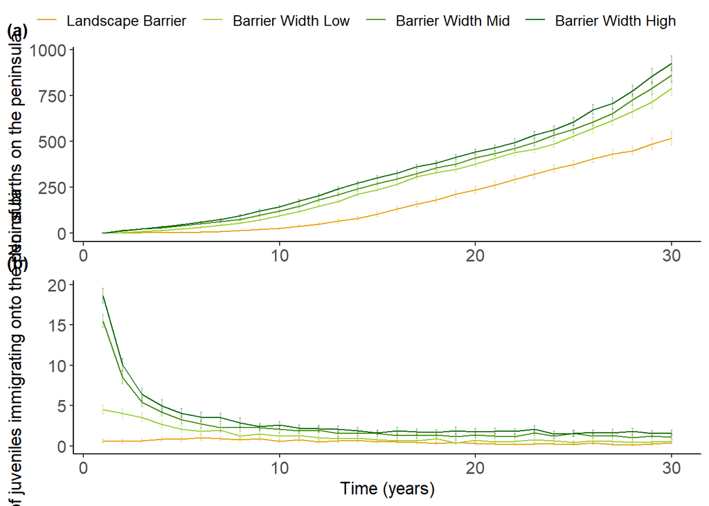

```r
print(birth_vs_immigration_plot_S1)
```

```r
# Optional - save plot

# ggsave(plot = birth_vs_immigration_plot_S1 , filename = paste0(main_wd, "\\Birth_vs_immigration_plot_Sensitivity1.png"), w = 21.5, h = 21.2, units = "cm", dpi = 800, device = "png" )
```

```r
### Plot S3a. Number of births ###

# Summarise the data
data_summary_births <- pest_final_births %>%
  group_by(scenario, year) %>%
  mutate(mean = rowMeans(across(where(is.numeric)))) %>%
  mutate(sd = matrixStats::rowSds(as.matrix(across(where(is.numeric))))) %>%
  mutate(se2 = se_func_fromsd(sd)) %>%
  filter(scenario %in% c('Landscape_barrier_23',
                         'ResKLow23',
                         'UrbanKLow23',
                         'UrbanKMid23',
                         'UrbanKHigh23'))

# Reorder factor levels for legend
data_summary_births$scenario <- factor(data_summary_births$scenario,
                                       levels = c('ResKLow23',
                                         'Landscape_barrier_23',
                                                  'UrbanKLow23',
                                                  'UrbanKMid23',
                                                  'UrbanKHigh23'))


# Create the number of births plot
nb_births_plot <-data_summary_births %>%
  ggplot(aes(x = year, y = mean)) +
  geom_line(aes(color = scenario)) +
  theme_classic() +  # set background white
  theme(axis.text = element_text(size=12), axis.title = element_text(size=12.5), legend.text = element_text(size=10.5)) +
  labs(x = "Time (years)", y = "No. of births on the peninsula") +  # define axis label
  geom_errorbar(aes(ymin = mean-se2, ymax = mean+se2, width=.1, color=scenario), alpha = 0.3)+
  scale_color_manual(name = "",
                     labels = c("Residential K Zero",
                                "Landscape Barrier",
                                "Urban K Low",
                                "Urban K Mid",
                                "Urban K High"),
                     values = c("tan4","#E69F00", "#00BFC4", "#00A9FF", "#000099"))


### Plot S3b. Immigration ###

# Summarise the data
data_summary_imm <- pest_final_imm %>%
  group_by(scenario, year) %>%
  mutate(mean = rowMeans(across(where(is.numeric)))) %>%
  mutate(sd = matrixStats::rowSds(as.matrix(across(where(is.numeric))))) %>%
  mutate(se2 = se_func_fromsd(sd)) %>%
  filter(scenario %in% c('ResKLow23',
                         'Landscape_barrier_23',
                         'UrbanKLow23',
                         'UrbanKMid23',
                         'UrbanKHigh23'))

# Reorder factor levels for legend
data_summary_imm$scenario <- factor(data_summary_imm$scenario,
                                    levels = c('ResKLow23',
                                               'Landscape_barrier_23',
                                               'UrbanKLow23',
                                               'UrbanKMid23',
                                               'UrbanKHigh23'))

# Create the immigration plot
nb_immigrants_plot <-data_summary_imm %>%
  ggplot(aes(x = year, y = mean)) +
  geom_line(aes(color = scenario)) +
  theme_classic() +  # set background white
  theme(axis.text = element_text(size=12), axis.title = element_text(size=12.5), legend.text = element_text(size=10.5)) +
  labs(x = "Time (years)", y = "No. of juveniles immigrating onto the peninsula") +  # define axis label
  geom_errorbar(aes(ymin = mean-se2, ymax = mean+se2, width=.1, color=scenario), alpha = 0.3)+
  scale_color_manual(name = "",
                     labels = c("Residential K Zero",
                                "Landscape Barrier",
                                "Urban K Low",
                                "Urban K Mid",
                                "Urban K High"),
                     values = c("tan4","#E69F00", "#00BFC4", "#00A9FF", "#000099"))


### Plot S3. Combined number of births and immigration ###

birth_vs_immigration_plot_S2 <- ggarrange(nb_births_plot + rremove("xlab"), nb_immigrants_plot, nrow = 2, ncol = 1, align = "v", common.legend = T, labels = c("(a)", "(b)"), label.x = -0.005,label.y = 1.10, font.label = list(size = 12))
```

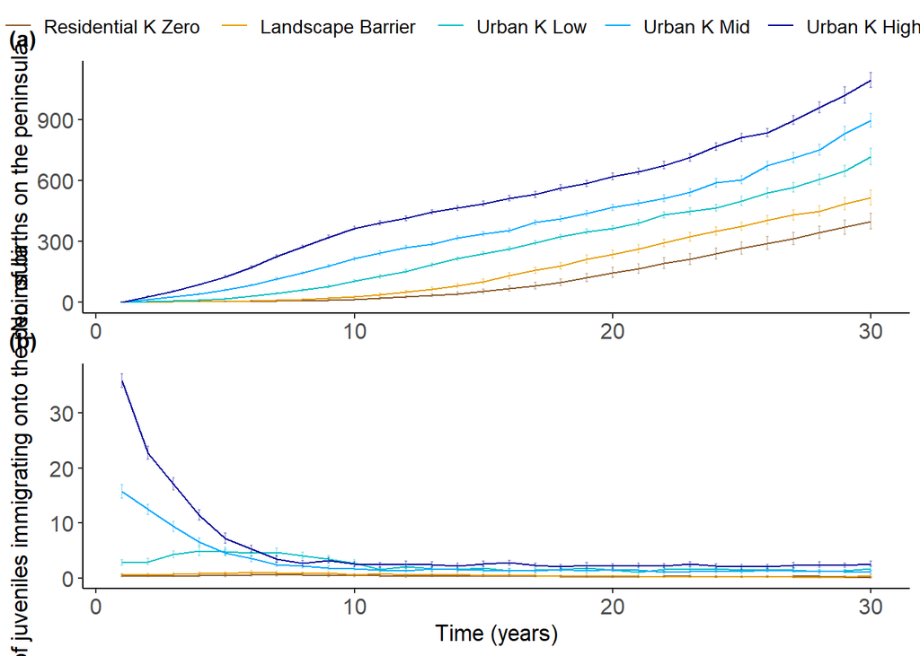

```r
print(birth_vs_immigration_plot_S2)
```

```r
# Optional - save plot

# ggsave(plot = birth_vs_immigration_plot_S2 , filename = paste0(main_wd, "\\Birth_vs_immigration_plot_Sensitivity2.png"), w = 21.5, h = 21.2, units = "cm", dpi = 800, device = "png" )
```

```r
### Plot S4a. Number of births ###

# Summarise the data
data_summary_births <- pest_final_births %>%
  group_by(scenario, year) %>%
  mutate(mean = rowMeans(across(where(is.numeric)))) %>%
  mutate(sd = matrixStats::rowSds(as.matrix(across(where(is.numeric))))) %>%
  mutate(se2 = se_func_fromsd(sd)) %>%
  filter(scenario %in% c('Landscape_barrier_23',
                         'BarLUrbanL23',
                         'BarHUrbanH23'))

# Reorder factor levels for legend
data_summary_births$scenario <- factor(data_summary_births$scenario,
                                       levels = c('Landscape_barrier_23',
                         'BarLUrbanL23',
                         'BarHUrbanH23'))


# Create the number of births plot
nb_births_plot <-data_summary_births %>%
  ggplot(aes(x = year, y = mean)) +
  geom_line(aes(color = scenario)) +
  theme_classic() +  # set background white
  theme(axis.text = element_text(size=12), axis.title = element_text(size=12.5), legend.text = element_text(size=10.5)) +
  labs(x = "Time (years)", y = "No. of births on the peninsula") +  # define axis label
  geom_errorbar(aes(ymin = mean-se2, ymax = mean+se2, width=.1, color=scenario), alpha = 0.3)+
  scale_color_manual(name = "",
                     labels = c("Landscape Barrier",
                                "Barrier Low Urban K Low",
                                "Barrier High Urban K High"),
                     values = c("#E69F00", "#C77CFF", "#FF61CC"))


### Plot S4b. Immigration ###

# Summarise the data
data_summary_imm <- pest_final_imm %>%
  group_by(scenario, year) %>%
  mutate(mean = rowMeans(across(where(is.numeric)))) %>%
  mutate(sd = matrixStats::rowSds(as.matrix(across(where(is.numeric))))) %>%
  mutate(se2 = se_func_fromsd(sd)) %>%
  filter(scenario %in% c('Landscape_barrier_23',
                         'BarLUrbanL23',
                         'BarHUrbanH23'))

# Reorder factor levels for legend
data_summary_imm$scenario <- factor(data_summary_imm$scenario,
                                    levels = c('Landscape_barrier_23',
                         'BarLUrbanL23',
                         'BarHUrbanH23'))

# Create the immigration plot
nb_immigrants_plot <-data_summary_imm %>%
  ggplot(aes(x = year, y = mean)) +
  geom_line(aes(color = scenario)) +
  theme_classic() +  # set background white
  theme(axis.text = element_text(size=12), axis.title = element_text(size=12.5), legend.text = element_text(size=10.5)) +
  labs(x = "Time (years)", y = "No. of juveniles immigrating onto the peninsula") +  # define axis label
  geom_errorbar(aes(ymin = mean-se2, ymax = mean+se2, width=.1, color=scenario), alpha = 0.3)+
  scale_color_manual(name = "",
                     labels = c("Landscape Barrier",
                                "Barrier Low Urban K Low",
                                "Barrier High Urban K High"),
                     values = c("#E69F00", "#C77CFF", "#FF61CC"))


### Plot S4. Combined number of births and immigration ###

birth_vs_immigration_plot_S3 <- ggarrange(nb_births_plot + rremove("xlab"), nb_immigrants_plot, nrow = 2, ncol = 1, align = "v", common.legend = T, labels = c("(a)", "(b)"), label.x = -0.005,label.y = 1.10, font.label = list(size = 12))
```

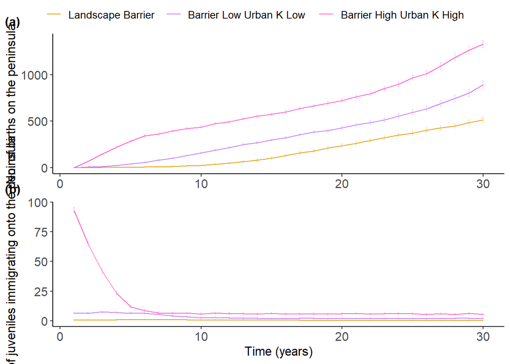

```r
print(birth_vs_immigration_plot_S3)
```

```r
# Optional - save plot

# ggsave(plot = birth_vs_immigration_plot_S3 , filename = paste0(main_wd, "\\Birth_vs_immigration_plot_Sensitivity3.png"), w = 21.5, h = 21.2, units = "cm", dpi = 800, device = "png" )
```

## Plot the number of juvenile mortalities during dispersal for a given density of possums on the peninsula (Figure 6)

```r
### Worst-case scenario (Incomplete elimination, no control) ###

# Initiate an empty data frame
pest_mort_prop <- NULL

# Loop over replicates
for (rep in seq(0,nb_replication-1)){

  # Set path to output file
  filename_nbpest <- paste0(main_wd, "Worst_case_23", '\\2.monthly_stat_rep_',rep,'.gz')

  # Read abundance, birth, and mortality files
  annual_stat_abun <- read.table(filename_nbpest) %>%
    .[, 1]

  annual_stat_abun<- (unname(tapply(annual_stat_abun, (seq_along(annual_stat_abun)-1) %/% 12, mean)))

  annual_stat_mort <- read.table(filename_nbpest) %>%
    .[, 4]

  annual_stat_mort<- (unname(tapply(annual_stat_mort, (seq_along(annual_stat_mort)-1) %/% 12, mean)))

  annual_stat_birth <- read.table(filename_nbpest) %>%
    .[, 3]

  annual_stat_birth<- (unname(tapply(annual_stat_birth, (seq_along(annual_stat_birth)-1) %/% 12, mean)))

  # Combine into one dataframe
  annual_stat <- cbind(annual_stat_abun, annual_stat_mort, annual_stat_birth) %>% as.data.frame()

  # Remove to just year 30
  annual_stat <- annual_stat[1:30,]

  # Calculate dispersal mortality divided over number of births
  annual_stat <- annual_stat %>%
    mutate(prop = (annual_stat_mort/annual_stat_birth)*100 ) %>%
     replace(is.na(.), 0) #replace NAs with 0

  # Calculate the proportion of mortality relative to population density
  if (rep == 0) {
    pest_mort_prop <- cbind(pest_mort_prop, (annual_stat[,1]/9782.834)) # Set abundance as density
    pest_mort_prop <- cbind(pest_mort_prop, annual_stat[,4])} # Mortality proportion

  else {
    pest_mort_prop <- rbind(pest_mort_prop, cbind((annual_stat[,1]/9782.834), annual_stat[,4]))

    }
}

 pest_final_WC <- as.data.frame(pest_mort_prop) %>% mutate(Scenario = "Incomplete elimination, no reinvasion control")


 ### Best-Case scenario (Complete elimination, high effort) ###

# Initiate an empty data frame
pest_mort_prop <- NULL

# Loop over replicates
for (rep in seq(0,nb_replication-1)){

  # Set path to output file
  filename_nbpest <- paste0(main_wd, 'Remove_high_23', '\\2.monthly_stat_rep_',rep,'.gz')

  # Read abundance, birth, and mortality files
  annual_stat_abun <- read.table(filename_nbpest) %>%
    .[, 1]

  annual_stat_abun<- (unname(tapply(annual_stat_abun, (seq_along(annual_stat_abun)-1) %/% 12, mean)))

  annual_stat_mort <- read.table(filename_nbpest) %>%
    .[, 4]

  annual_stat_mort<- (unname(tapply(annual_stat_mort, (seq_along(annual_stat_mort)-1) %/% 12, mean)))

  annual_stat_birth <- read.table(filename_nbpest) %>%
    .[, 3]

  annual_stat_birth<- (unname(tapply(annual_stat_birth, (seq_along(annual_stat_birth)-1) %/% 12, mean)))

  # Combine into one dataframe
  annual_stat <- cbind(annual_stat_abun, annual_stat_mort, annual_stat_birth) %>% as.data.frame()

  # Remove to just year 30
  annual_stat <- annual_stat[1:30,]

  # Calculate dispersal mortality divided over number of births
  annual_stat <- annual_stat %>%
    mutate(prop = (annual_stat_mort/annual_stat_birth)*100 ) %>%
     replace(is.na(.), 0) #replace NAs with 0

  # Calculate the proportion of mortality relative to population density
  if (rep == 0) {
    pest_mort_prop <- cbind(pest_mort_prop, (annual_stat[,1]/9782.834)) # Set abundance as density
    pest_mort_prop <- cbind(pest_mort_prop, annual_stat[,4])} # Mortality proportion

  else {
    pest_mort_prop <- rbind(pest_mort_prop, cbind((annual_stat[,1]/9782.834), annual_stat[,4]))

    }
}

 pest_final_BC <- as.data.frame(pest_mort_prop) %>% mutate(Scenario = "Complete elimination, moderate reinvasion control")



### Landscape barrier scenario (Complete elimination, no control) ###


# Initiate an empty data frame
pest_mort_prop <- NULL

# Loop over replicates
for (rep in seq(0,nb_replication-1)){

  # Set path to output file
  filename_nbpest <- paste0(main_wd, "Landscape_barrier_23", '\\2.monthly_stat_rep_',rep,'.gz')

  # Read abundance, birth, and mortality files
  annual_stat_abun <- read.table(filename_nbpest) %>%
    .[, 1]

  annual_stat_abun<- (unname(tapply(annual_stat_abun, (seq_along(annual_stat_abun)-1) %/% 12, mean)))

  annual_stat_mort <- read.table(filename_nbpest) %>%
    .[, 4]

  annual_stat_mort<- (unname(tapply(annual_stat_mort, (seq_along(annual_stat_mort)-1) %/% 12, mean)))

  annual_stat_birth <- read.table(filename_nbpest) %>%
    .[, 3]

  annual_stat_birth<- (unname(tapply(annual_stat_birth, (seq_along(annual_stat_birth)-1) %/% 12, mean)))

  # Combine into one dataframe
  annual_stat <- cbind(annual_stat_abun, annual_stat_mort, annual_stat_birth) %>% as.data.frame()

  # Remove to just year 30
  annual_stat <- annual_stat[1:30,]

  # Calculate dispersal mortality divided over number of births
  annual_stat <- annual_stat %>%
    mutate(prop = (annual_stat_mort/annual_stat_birth)*100 ) %>%
     replace(is.na(.), 0) #replace NAs with 0

  # Calculate the proportion of mortality relative to population density
  if (rep == 0) {
    pest_mort_prop <- cbind(pest_mort_prop, (annual_stat[,1]/9782.834)) # Set abundance as density
    pest_mort_prop <- cbind(pest_mort_prop, annual_stat[,4])} # Mortality proportion

  else {
    pest_mort_prop <- rbind(pest_mort_prop, cbind((annual_stat[,1]/9782.834), annual_stat[,4]))

    }

}

pest_final_LB <- as.data.frame(pest_mort_prop) %>% mutate(Scenario = "Complete elimination, no reinvasion control")

### Figure 7 - combine scenarios ###

pest_final <- rbind(pest_final_WC, pest_final_BC, pest_final_LB)

colnames(pest_final) <- c("Density", "Proportion", "Scenario")

# Reorder factor levels for legend
pest_final$Scenario <- factor(pest_final$Scenario,
                                       levels = c("Complete elimination, no reinvasion control",
                                                  'Incomplete elimination, no reinvasion control',
                                                  'Complete elimination, moderate reinvasion control'))

mort_prop_plot_BOTH <- pest_final %>%
  ggplot(aes(x = Density, y = Proportion, color = Scenario)) +
  geom_point(alpha = 0.1) +
  geom_smooth(method = "gam", linewidth = 0.7, se = F)+
  theme_classic() +  # set background white
  theme(axis.text = element_text(size=12), axis.title = element_text(size=14), legend.text = element_text(size=10.5), legend.position = c(.75, .2)) +
  labs(x = expression(paste("Possum density on peninsula (ha" ^ "1", ")")), y = "Annual % of juvenile mortality vs. births")

mort_prop_plot_BOTH <- mort_prop_plot_BOTH + scale_fill_manual(values = c("#E69F00", "#56B4E9", "#660066")) +
  scale_color_manual(values = c("#E69F00", "#56B4E9", "#660066"),
                                         name = "")
```

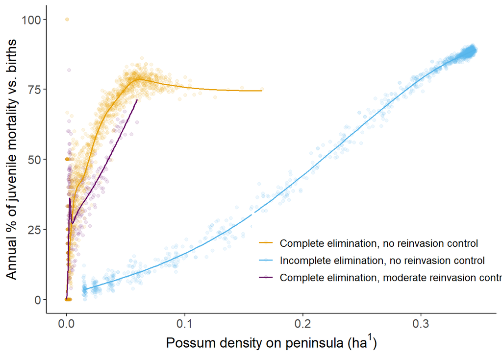

```r
print(mort_prop_plot_BOTH)
```

```r
# Optional - save plot

# ggsave(plot = mort_prop_plot_BOTH , filename = paste0(main_wd, "\\Juvenile_mortality_vs_birth_PLOT_withTHIRDscenario_single_plot.png"), w = 21, h = 14, units = "cm", dpi = 800, device = "png" )
```

## Plot the number of juvenile mortalities during dispersal for a given density of possums on the peninsula for the senstivity analysis (Figure S5)

```r
### Barrier Width High ###

# Initiate an empty data frame
pest_mort_prop <- NULL

# Loop over replicates
for (rep in seq(0,nb_replication-1)){

  # Set path to output file
  filename_nbpest <- paste0(main_wd, "BarrierWidthHigh23", '\\2.monthly_stat_rep_',rep,'.gz')

  # Read abundance, birth, and mortality files
  annual_stat_abun <- read.table(filename_nbpest) %>%
    .[, 1]

  annual_stat_abun<- (unname(tapply(annual_stat_abun, (seq_along(annual_stat_abun)-1) %/% 12, mean)))

  annual_stat_mort <- read.table(filename_nbpest) %>%
    .[, 4]

  annual_stat_mort<- (unname(tapply(annual_stat_mort, (seq_along(annual_stat_mort)-1) %/% 12, mean)))

  annual_stat_birth <- read.table(filename_nbpest) %>%
    .[, 3]

  annual_stat_birth<- (unname(tapply(annual_stat_birth, (seq_along(annual_stat_birth)-1) %/% 12, mean)))

  # Combine into one dataframe
  annual_stat <- cbind(annual_stat_abun, annual_stat_mort, annual_stat_birth) %>% as.data.frame()

  # Remove to just year 30
  annual_stat <- annual_stat[1:30,]

  # Calculate dispersal mortality divided over number of births
  annual_stat <- annual_stat %>%
    mutate(prop = (annual_stat_mort/annual_stat_birth)*100 ) %>%
     replace(is.na(.), 0) #replace NAs with 0

  # Calculate the proportion of mortality relative to population density
  if (rep == 0) {
    pest_mort_prop <- cbind(pest_mort_prop, (annual_stat[,1]/9782.834)) # Set abundance as density
    pest_mort_prop <- cbind(pest_mort_prop, annual_stat[,4])} # Mortality proportion

  else {
    pest_mort_prop <- rbind(pest_mort_prop, cbind((annual_stat[,1]/9782.834), annual_stat[,4]))

    }
}

 pest_final_BH <- as.data.frame(pest_mort_prop) %>% mutate(Scenario = "Barrier Width High")


 ### Urban K High ###

# Initiate an empty data frame
pest_mort_prop <- NULL

# Loop over replicates
for (rep in seq(0,nb_replication-1)){

  # Set path to output file
  filename_nbpest <- paste0(main_wd, 'UrbanKHigh23', '\\2.monthly_stat_rep_',rep,'.gz')

  # Read abundance, birth, and mortality files
  annual_stat_abun <- read.table(filename_nbpest) %>%
    .[, 1]

  annual_stat_abun<- (unname(tapply(annual_stat_abun, (seq_along(annual_stat_abun)-1) %/% 12, mean)))

  annual_stat_mort <- read.table(filename_nbpest) %>%
    .[, 4]

  annual_stat_mort<- (unname(tapply(annual_stat_mort, (seq_along(annual_stat_mort)-1) %/% 12, mean)))

  annual_stat_birth <- read.table(filename_nbpest) %>%
    .[, 3]

  annual_stat_birth<- (unname(tapply(annual_stat_birth, (seq_along(annual_stat_birth)-1) %/% 12, mean)))

  # Combine into one dataframe
  annual_stat <- cbind(annual_stat_abun, annual_stat_mort, annual_stat_birth) %>% as.data.frame()

  # Remove to just year 30
  annual_stat <- annual_stat[1:30,]

  # Calculate dispersal mortality divided over number of births
  annual_stat <- annual_stat %>%
    mutate(prop = (annual_stat_mort/annual_stat_birth)*100 ) %>%
     replace(is.na(.), 0) #replace NAs with 0

  # Calculate the proportion of mortality relative to population density
  if (rep == 0) {
    pest_mort_prop <- cbind(pest_mort_prop, (annual_stat[,1]/9782.834)) # Set abundance as density
    pest_mort_prop <- cbind(pest_mort_prop, annual_stat[,4])} # Mortality proportion

  else {
    pest_mort_prop <- rbind(pest_mort_prop, cbind((annual_stat[,1]/9782.834), annual_stat[,4]))

    }
}

 pest_final_UH <- as.data.frame(pest_mort_prop) %>% mutate(Scenario = "Urban K High")



 ### Residential K Zero ###

# Initiate an empty data frame
pest_mort_prop <- NULL

# Loop over replicates
for (rep in seq(0,nb_replication-1)){

  # Set path to output file
  filename_nbpest <- paste0(main_wd, 'ResKLow23', '\\2.monthly_stat_rep_',rep,'.gz')

  # Read abundance, birth, and mortality files
  annual_stat_abun <- read.table(filename_nbpest) %>%
    .[, 1]

  annual_stat_abun<- (unname(tapply(annual_stat_abun, (seq_along(annual_stat_abun)-1) %/% 12, mean)))

  annual_stat_mort <- read.table(filename_nbpest) %>%
    .[, 4]

  annual_stat_mort<- (unname(tapply(annual_stat_mort, (seq_along(annual_stat_mort)-1) %/% 12, mean)))

  annual_stat_birth <- read.table(filename_nbpest) %>%
    .[, 3]

  annual_stat_birth<- (unname(tapply(annual_stat_birth, (seq_along(annual_stat_birth)-1) %/% 12, mean)))

  # Combine into one dataframe
  annual_stat <- cbind(annual_stat_abun, annual_stat_mort, annual_stat_birth) %>% as.data.frame()

  # Remove to just year 30
  annual_stat <- annual_stat[1:30,]

  # Calculate dispersal mortality divided over number of births
  annual_stat <- annual_stat %>%
    mutate(prop = (annual_stat_mort/annual_stat_birth)*100 ) %>%
     replace(is.na(.), 0) #replace NAs with 0

  # Calculate the proportion of mortality relative to population density
  if (rep == 0) {
    pest_mort_prop <- cbind(pest_mort_prop, (annual_stat[,1]/9782.834)) # Set abundance as density
    pest_mort_prop <- cbind(pest_mort_prop, annual_stat[,4])} # Mortality proportion

  else {
    pest_mort_prop <- rbind(pest_mort_prop, cbind((annual_stat[,1]/9782.834), annual_stat[,4]))

    }
}

 pest_final_RL <- as.data.frame(pest_mort_prop) %>% mutate(Scenario = "Residential K Zero")

### Barrier High Urban High ###


# Initiate an empty data frame
pest_mort_prop <- NULL

# Loop over replicates
for (rep in seq(0,nb_replication-1)){

  # Set path to output file
  filename_nbpest <- paste0(main_wd, "BarHUrbanH23", '\\2.monthly_stat_rep_',rep,'.gz')

  # Read abundance, birth, and mortality files
  annual_stat_abun <- read.table(filename_nbpest) %>%
    .[, 1]

  annual_stat_abun<- (unname(tapply(annual_stat_abun, (seq_along(annual_stat_abun)-1) %/% 12, mean)))

  annual_stat_mort <- read.table(filename_nbpest) %>%
    .[, 4]

  annual_stat_mort<- (unname(tapply(annual_stat_mort, (seq_along(annual_stat_mort)-1) %/% 12, mean)))

  annual_stat_birth <- read.table(filename_nbpest) %>%
    .[, 3]

  annual_stat_birth<- (unname(tapply(annual_stat_birth, (seq_along(annual_stat_birth)-1) %/% 12, mean)))

  # Combine into one dataframe
  annual_stat <- cbind(annual_stat_abun, annual_stat_mort, annual_stat_birth) %>% as.data.frame()

  # Remove to just year 30
  annual_stat <- annual_stat[1:30,]

  # Calculate dispersal mortality divided over number of births
  annual_stat <- annual_stat %>%
    mutate(prop = (annual_stat_mort/annual_stat_birth)*100 ) %>%
     replace(is.na(.), 0) #replace NAs with 0

  # Calculate the proportion of mortality relative to population density
  if (rep == 0) {
    pest_mort_prop <- cbind(pest_mort_prop, (annual_stat[,1]/9782.834)) # Set abundance as density
    pest_mort_prop <- cbind(pest_mort_prop, annual_stat[,4])} # Mortality proportion

  else {
    pest_mort_prop <- rbind(pest_mort_prop, cbind((annual_stat[,1]/9782.834), annual_stat[,4]))

    }

}

pest_final_BHUH <- as.data.frame(pest_mort_prop) %>% mutate(Scenario = "Barrier High Urban K High")

### Landscape barrier scenario  ###


# Initiate an empty data frame
pest_mort_prop <- NULL

# Loop over replicates
for (rep in seq(0,nb_replication-1)){

  # Set path to output file
  filename_nbpest <- paste0(main_wd, "Landscape_barrier_23", '\\2.monthly_stat_rep_',rep,'.gz')

  # Read abundance, birth, and mortality files
  annual_stat_abun <- read.table(filename_nbpest) %>%
    .[, 1]

  annual_stat_abun<- (unname(tapply(annual_stat_abun, (seq_along(annual_stat_abun)-1) %/% 12, mean)))

  annual_stat_mort <- read.table(filename_nbpest) %>%
    .[, 4]

  annual_stat_mort<- (unname(tapply(annual_stat_mort, (seq_along(annual_stat_mort)-1) %/% 12, mean)))

  annual_stat_birth <- read.table(filename_nbpest) %>%
    .[, 3]

  annual_stat_birth<- (unname(tapply(annual_stat_birth, (seq_along(annual_stat_birth)-1) %/% 12, mean)))

  # Combine into one dataframe
  annual_stat <- cbind(annual_stat_abun, annual_stat_mort, annual_stat_birth) %>% as.data.frame()

  # Remove to just year 30
  annual_stat <- annual_stat[1:30,]

  # Calculate dispersal mortality divided over number of births
  annual_stat <- annual_stat %>%
    mutate(prop = (annual_stat_mort/annual_stat_birth)*100 ) %>%
     replace(is.na(.), 0) #replace NAs with 0

  # Calculate the proportion of mortality relative to population density
  if (rep == 0) {
    pest_mort_prop <- cbind(pest_mort_prop, (annual_stat[,1]/9782.834)) # Set abundance as density
    pest_mort_prop <- cbind(pest_mort_prop, annual_stat[,4])} # Mortality proportion

  else {
    pest_mort_prop <- rbind(pest_mort_prop, cbind((annual_stat[,1]/9782.834), annual_stat[,4]))

    }

}

pest_final_LB <- as.data.frame(pest_mort_prop) %>% mutate(Scenario = "Landscape Barrier")

### Figure 7 - combine scenarios ###

pest_final <- rbind(pest_final_BH, pest_final_RL, pest_final_UH, pest_final_BHUH, pest_final_LB)

colnames(pest_final) <- c("Density", "Proportion", "Scenario")

# Reorder factor levels for legend
pest_final$Scenario <- factor(pest_final$Scenario,
                                       levels = c("Residential K Zero",
                                                  "Landscape Barrier",
                                                  "Barrier Width High",
                                                  "Urban K High",
                                                  "Barrier High Urban K High"))

mort_prop_plot_BOTH_sensitivity <- pest_final %>%
  ggplot(aes(x = Density, y = Proportion, color = Scenario)) +
  geom_point(alpha = 0.1) +
  geom_smooth(method = "gam", linewidth = 0.7, se = F)+
  theme_classic() +  # set background white
  theme(axis.text = element_text(size=12), axis.title = element_text(size=14), legend.text = element_text(size=10.5), legend.position = c(.75, .2)) +
  labs(x = expression(paste("Possum density on peninsula (ha" ^ "1", ")")), y = "Annual % of juvenile mortality vs. births")

mort_prop_plot_BOTH_sensitivity <- mort_prop_plot_BOTH_sensitivity + scale_fill_manual(values = c("tan4","#E69F00", "darkgreen", "#000099", "#FF61CC")) +
  scale_color_manual(values = c("tan4","#E69F00", "darkgreen", "#000099", "#FF61CC"),
                                         name = "")
```

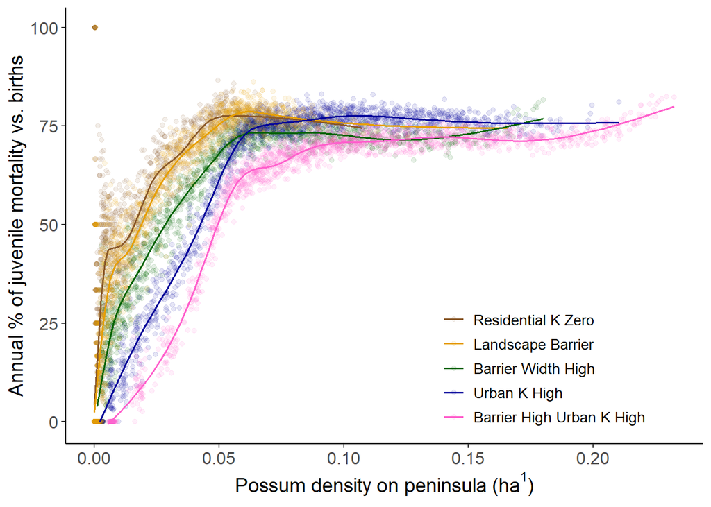

```r
print(mort_prop_plot_BOTH_sensitivity)
```

```r
# Optional - save plot

# ggsave(plot = mort_prop_plot_BOTH_sensitivity , filename = paste0(main_wd, "\\Juvenile_mortality_vs_birth_PLOT_sensitivity_analysis_w_RESIDENTIAL.png"), w = 21, h = 14, units = "cm", dpi = 800, device = "png" )
```

```r
# Set the subset scenarios for plotting
result_subf_subset <- list('Worst_case_23',
                           'Remove_high_23',
                    'Landscape_barrier_23')

# Time sequence (year 20 and year 30)
time_sequence <- c(239, 359)

# Set up the function to calculate the mean density for each time step and scenario
mean_den_ascii_func <- function(result_subf) {

  # Create output directory per scenario
  output_dir<-dir.create(paste0(main_wd,"Figures",result_subf,"\\OUTPUTASCII"))

  for (timestep in time_sequence){

  # Loop over all replicates
  for (rep in seq(0,nb_replication-1)){

    # Set path
    filename_nbpest <- paste0(main_wd, result_subf, '\\distribution_rep_',rep,'\\distribution_overTime_',timestep,'_rep_',rep,'.gz')

    # Read abundance file, convert to density (dividing by area of Otago Peninsula)
    density <- (read.table(filename_nbpest))/9782.834

    # At the first replicate, initiate a data frame. Otherwise add the density of possums in each grid cell.
    if (rep == 0) {pest_density_temp <- density} else {
      pest_density_temp <- pest_density_temp  + density}}

  # Calculate the mean density of possums per grid cell (averaged over replicates)
  mean_density <- pest_density_temp / nb_replication

  # Rename columns to be numbers
  colnames(mean_density) <- ncol(mean_density):1

  # Transpose so the x axis replaces the y and vice versa
  transpose <- t(mean_density)

  # Reshape into a matrix, and then dataframe
  reshape_data  <- melt( as.matrix(transpose) )

  # Reshape again to a dataframe which will just have 3 columns
  reshape_data <- as.data.frame(reshape_data)

  colnames(reshape_data) <- c('x', 'y', 'density')

  # Load the template ascii to have projected grid coordinates
  template_ascii <- raster(paste0(main_wd,"template_raster"))

  # Convert to a dataframe
  template_ascii_df <- cbind(coordinates(template_ascii), as.data.frame(template_ascii))

  # Reshape to also include the column 'density' from the mean_density dataframe
  template_ascii_df$density <- reshape_data$density

  # Subset to have three columns
  final_df <- subset(template_ascii_df, select = c("x", "y", "density"))
  #raterize
  density_rast <- rasterFromXYZ(final_df)

  # writeRaster(density_rast,filename = paste0(main_wd, "Figures", result_subf, "\\OUTPUTASCII\\meandensity_ascii_time_", timestep,".asc"), format='ascii', overwrite = T)

  }
}

result_subf_subset %>%
  map(mean_den_ascii_func)
```

## References

Lustig, A., James, A., Anderson, D., Plank, M., 2019. Pest control at a regional scale: Identifying key criteria using a spatially explicit, agent-based model. Journal of Applied Ecology 56, 1515–1527. https://doi.org/10.1111/1365-2664.13387

Patterson, C.R., Lustig, A., Seddon, P.J., Wilson, D., van Heezik, Y., 2023. Eradicating an invasive mammal requires local elimination and reduced reinvasion from urban source population.